# Ceci n’est pas une pipe

Erin

2017-03-23

# What is the Pipe?

# Magritte’s The Treachery of Images

# Introduction to R’s Not-a-Pipe: %>%

I was once told me that `%>%` is called not-a-pipe since *pipe* was already taken for another symbol (|), but considering it is from the magrittr package, I believe the real story is based on Magritte’s famous image.

# What is the pipe?

[figure not shown]

- The pipe leads the OUTPUT of one command into the INPUT of the next one.
- Functions in the *Tidyverse* are written to work well with the pipe

For example, to filter a data frame and add a new column you would…

```r
x <- filter(mpg, hwy >= 31)
newx <- mutate(x, hwy.kpl = hwy * 0.4251)
```

But you could also pipe in the input to the next command.

```r
x <- mpg %>%
  filter(hwy >= 31) %>%
  mutate(hwy.kpl = hwy * 0.4251)
```

# Data First

Notice how the the data frame is always the first argument to these functions.

- When writing your OWN functions, if you want to use them in a pipe sequence remember that the dataframe must be the first argument
- A surprsing number of other functions in R are NOT desgined with data frist, so you have to do some work to use them in a pipe:
- `lm(y ~ x, data=data)` does not have the data as the first argument

# Examples

The pipe makes combining output from various different functions much easier to write and read.

```r
#Option A:
mutate(
      filter(iris, Sepal.Width > 4),
    total_width = Sepal.Width + Petal.Width
  )
```

```
##   Sepal.Length Sepal.Width Petal.Length Petal.Width Species total_width
## 1          5.7         4.4          1.5         0.4  setosa         4.8
## 2          5.2         4.1          1.5         0.1  setosa         4.2
## 3          5.5         4.2          1.4         0.2  setosa         4.4
```

This code computes the same output as before, but is much easier to read.

Rember, code should be written to be understood by **future you**. Make future you happy!

```r
#Option B:
iris %>%
  filter(Sepal.Width > 4) %>%
  mutate(total_width = Sepal.Width + Petal.Width)
```

```
##   Sepal.Length Sepal.Width Petal.Length Petal.Width Species total_width
## 1          5.7         4.4          1.5         0.4  setosa         4.8
## 2          5.2         4.1          1.5         0.1  setosa         4.2
## 3          5.5         4.2          1.4         0.2  setosa         4.4
```

# Story Time

The story

```
Little bunny Foo Foo
Went hopping through the forest
Scooping up the field mice
And bopping them on the head
```

[figure not shown]

# Story Time

The story

```
Little bunny Foo Foo
Went hopping through the forest
Scooping up the field mice
And bopping them on the head
```

Could look like this in code. Where each step Foo Foo takes is a new function.

```r
foo_foo <- little_bunny()
foo_foo_1 <- hop(foo_foo, through = forest)
foo_foo_2 <- scoop(foo_foo_1, up = field_mice)
foo_foo_3 <- bop(foo_foo_2, on = head)
```

# Story Time

```r
bop(
  scoop(
    hop(foo_foo, through = forest),
    up = field_mice
  ),
  on = head
)
```

is much more confusing than…

# Story Time

```r
bop(
  scoop(
    hop(foo_foo, through = forest),
    up = field_mice
  ),
  on = head
)
```

is much more confusing than…

```r
foo_foo %>%
  hop(through = forest) %>%
  scoop(up = field_mouse) %>%
  bop(on = head)
)
```

# Your Turn

What quick story can you tell using the pipe?

# Your Turn

What quick story can you tell using the pipe?

```
humpty_dumpty %>%
  sat(on = wall) %>%
  fall(type = great) %>%
  left_join(kings_horses) %>%
  left_join(kings_men) %>%
  put_together(FALSE)
```

[figure not shown]

# Difference bettween piping and not piping.

You tell me, what is happening in this code?!

```r
hourly_delay <- filter(
  summarise(
    group_by(
      filter(flights, !is.na(dep_delay)),
      date, hour),
    delay = mean(dep_delay),
    n = n()),
  n > 10
)
```

Is this easier to understand?

```r
hourly_delay <- flights %>%
  filter(!is.na(dep_delay)) %>%
  group_by(date, hour) %>%
  summarise(
    delay = mean(dep_delay),
    n = n()
  ) %>%
  filter(n > 10)
```

# Rules for Piping

# as borrowed from Bob Rudis

# Rules for Piping

1. The pipe chain should be larger than 1
2. A pipe group should be desgined to complete a specific task
3. It is okay to change objects along the pipe (i.e pass in a dataframe and output a plot)
4. Be data source aware
5. Pipe operations should be “atomic”
6. Keep your pipes “short”

### Pipe Chain should be larger than 1

Do not do this

```r
df %>% str()
```

when

```r
str(df)
```

is so much more compact and easier to read.

### A pipe group should be designed to complete a specific task

Keeping a pipe group to one task will help with further rules (specifically length).

[figure not shown]

### It is okay to change objects along the pipe

Most commonly, you might go from a dataframe to a plot, or a list to a dataframe.

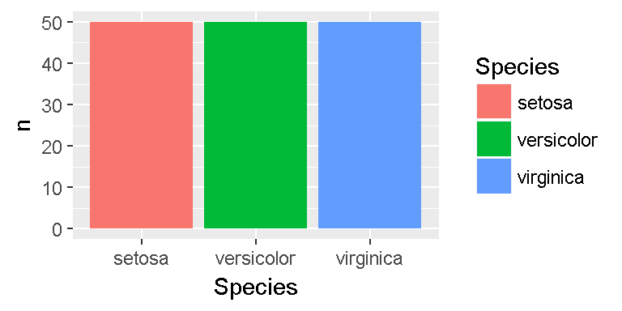

```r
iris %>%
  count(Species, sort=TRUE) %>%
  mutate(Species=factor(Species, levels=Species)) %>%
  ggplot(aes(Species, n, fill=Species)) + geom_col()
```

### Pipe operators should be “atomic”

- This means that your pipe can have as many steps as want, but in the end should be doing ONE thing. This is to prevent wasting time if something goes wrong at the end of the pipe, making you start again.
- The other gotcha is getting a nice plot but losing the data behind it. It’s a similar problem, but it’s an easy trap to fall into. (I do this all the time! Bad Erin.)

### Keep your pipes “short”

All this to say, keep your pipes long enough to not add more confusion, and short enough to avoid breaking things. You’ll find that you’ll quickly discover what the right “length” for you is.

# Discussion Questions

# Discussion Questions

- When should you use the pipe vs not?
- Beside ease of writing/reading what is useful about using the pipe structure?
- What should you never do in a pipe group?